# Price Analysis

Lecture note

Author

Affiliation

Dejene, G.

[UiT The Arctic University of Norway](https://uit.no/ansatte/dejene.g.kidane)

Published

September 18, 2024

# 1. Introduction

- Price analysis is an important area of research in economics.
- Price signal transmission is one type of price analysis.
- Price signal transmission can integrate different markets

  (e.g., von Cramon-Taubadel & Meyer, 2004).
- Economists study price transmission analysis to study:
  - market competition,
  - market performance,
  - market efficiency
  - market integration, etc.

# 2. What is Price Transmission?

- Price transmission is when a change in price in one market causes price to change in another related market.
- **Three types of price transmission**:

  **a) Vertical price transmission:**
  - b/n two points (marketing stages) along the supply chain.
  - For instance, between farm and retail level markets.

    e.g., price of wheat –> price of flour,

    salmon prices at export market of Norway and prices of salmon products in the retail market of France

  **Articles to read:** Asche et al.(2011), Asche et al. (2014), Vavra and Goodwin (2005).

  **b) Spatial price transmission:**
  - b/n two markets for same/homogeneous commodity.

  ```
  e.g., price of wheat in US and price of wheat in Canada

      price of cod in Germany and France
  ```

  **Articles to read:** Goodwin & Schroeder (1991), Ardeni (1989), Asche et al. (2004).

  **c) Cross-commodity price transmission:**
  - b/n two commodities
  - e.g., price of maize and price of rice,

  ```
  price of salmon and price of Cod in France
  ```

**Note:** Spatial and cross price transmission often called Horizontal price transmission/or market integration/.

# 3. Why is it useful to study price transmission?

- Study of price transmission helps to diagnose poorly functioning markets

  e.g., If two markets are close together, but show little price transmission, this might indicate problems with transportation network or monopolistic practices.
- Study of price transmission may help assess the extent of competition in a market

  e.g., Quick and complete price transmission b/n markets can be taken as an indication of high competition.
- Study of price transmission may help forecast prices based on trends in related prices

  e.g., If changes in soybean prices transmit to sunflower markets, then soybean futures markets may predict sunflower prices

# 4. Price Transmission Methodology

- A wide variety of empirical techniques are used in the literature to study price transmission.
- Cointegration is the most widely used approach.
- The two most common cointegration approaches are: the Engle-Granger & Johansen cointegration

## 4.1. The Engle-Granger cointegration approach

- It is also called a two-stages approach.

**First Stage:**

- If $p_{1,t}$ and $p_{2,t}$ are prices in two distinct markets at time $t$ ( expressed in log form), estimate:

$$p_{2,t} = \beta_1 + \beta_2 p_{1,t} + \mu_t$$

where $\mu_t$ is the error term.

- $\beta_2$ - is interpreted as elasticity of price transmission and defines the relationship b/n the prices
- $\beta_2=1,$ perfect price transmission / Law of One Price (LOP) , and $\beta_2 =0$ completely segmented markets.
- $0 < \beta_2 <1$ integrated but not perfectly integrated

**Second Stage:**

- Retrieve the residuals from the long-run model above and use OLS to estimate the equation:

$$\Delta \mu_t = \rho \mu_{t-1} + \sum_{i=1}^p\gamma_i \Delta \mu_{t-i} +v_t$$

- Hypothesis Test: $H_0:$ no co-integration ($\rho =0$) vs $H_1:$ cointegration
- If the null hypothesis $H_0:$ is rejected, we can estimate VECM. Otherwise we estimate VAR model in first difference
- Estimate **(Vector) Error Correction Model:**

$$\Delta p_{1,t} = \alpha_0 + \rho ECT_{t-1} +v_{1,t}$$
$$\Delta p_{2,t} = \gamma_0 + \rho ECT_{t-1} +v_{2,t}$$

where $\mu_{t-1} = p_{2,t-1}-\beta_1-\beta_2p_{1,t-1} =: ECT_{t-1}$

- Including more lags of each of the prices in the models to make the model more parsimonious, we have:

$$\Delta p_{1,t} = \alpha_0 + \rho ECT_{t-1}+ \sum_{i=1}^{k1} \Delta p_{1,t-i}+ \sum_{j=1}^{k2} \Delta p_{2,t-j} +v_{2,t}$$
$$\Delta p_{2,t} = \gamma_0 + \rho ECT_{t-1}+ \sum_{i=1}^{k2} \Delta p_{1,t-i}+ \sum_{j=1}^{k1} \Delta p_{2,t-j} +v_{2,t}$$

## 4.2. The Johansen cointegration approach

- The Engle-Granger approach is limited to bivariate variables, while the Johansen approach is a multivariate approach
- Furthermore, in the Engle-Granger approach, it is not clear which price to take as a dependent variable. Therefore, we have to determine that using the nature of the market or using weak exogeneity test. However, this is not an issue in when using the Johansen approach.
- Given a vector of prices, $P_t=[p_{1,t},p_{2,t}]$, the Johansen cointegration approach in a Vector Error Correction form is given as follows:

$$\Delta P_{t} = \alpha_0 + \Pi P_{t-1} + \sum_{i=1}^{k-1} \Delta P_{t-i} +u_t$$

# Price Transmission along the salmon supply chain

- **Objective:**
  - investigate the relationship between the Norwegian salmon export price with different salmon-product prices (e.g., fresh and smoked salmon) in the retail markets of France

```r
#get the data
library(readr)
salmon_prices <- read_delim("https://raw.githubusercontent.com/uit-sok-3008-h23/uit-sok-3008-h23.github.io/main/salmon_prices.csv",
    delim = ";", escape_double = FALSE, trim_ws = TRUE)

#rename
mydata <- salmon_prices
head(mydata)
```

```
# A tibble: 6 × 5
   Year Month Export fresh smoked
  <dbl> <dbl>  <dbl> <dbl>  <dbl>
1  2008     1   3.27  8.83   14.4
2  2008     2   3.21  8.95   13.4
3  2008     3   3.37  8.38   13.3
4  2008     4   3.25  8.95   13.3
5  2008     5   3.41  8.53   13.4
6  2008     6   3.31  8.66   13.3
```

- The prices:

```r
Export <- mydata$Export
Fresh <- mydata$fresh
Smoked <- mydata$smoked
```

```r
# Descriptive statistics of the prices
summary(Export)
```

```
   Min. 1st Qu.  Median    Mean 3rd Qu.    Max.
  2.910   3.660   4.790   4.834   5.665   8.010
```

```r
summary(Fresh)
```

```
   Min. 1st Qu.  Median    Mean 3rd Qu.    Max.
   8.19    9.13   10.69   10.86   11.71   15.37
```

```r
summary(Smoked)
```

```
   Min. 1st Qu.  Median    Mean 3rd Qu.    Max.
  12.69   14.40   15.61   16.05   17.27   21.46
```

- Plot of the prices

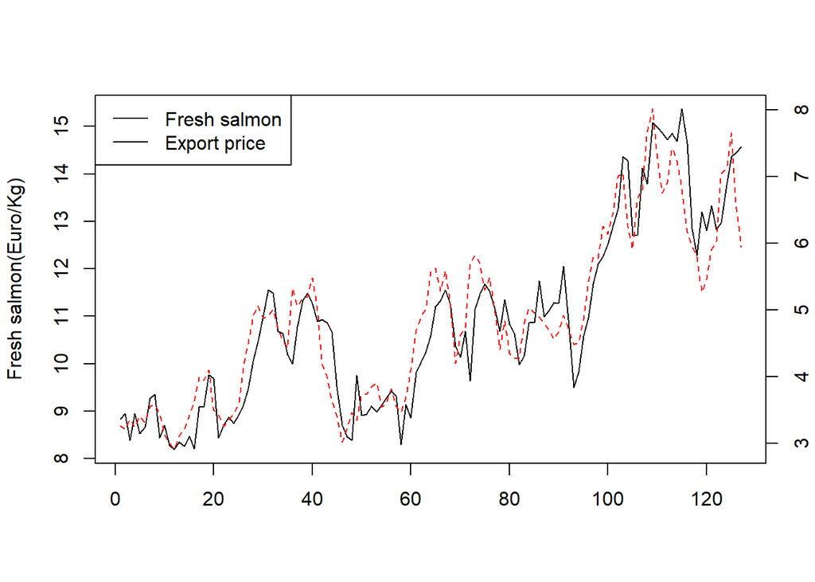

```r
# plot the prices

#plot of of prices, Fresh salmon vs export price
plot(Fresh, type ="l", ylab = "Fresh salmon(Euro/Kg)",
     main = "", xlab = "",
     col = "black")
par(new=TRUE)
plot(Export, type = "l", xaxt = "n", yaxt = "n",
     ylab = "", xlab = "", col = "red", lty = 2)
axis(side = 4)
mtext("Export Price(Euro/Kg)", side = 4, line = 3)

legend("topleft", c("Fresh salmon", "Export price"),
       col = c("black", "black"), lty = c(1, 1))
```

- Transform the prices to log prices

```r
lexport <- log(Export)
lfresh <- log(Fresh)
lsmoked <- log(Smoked)
```

- Convert the prices to time series data:

```r
lexport=ts(lexport,start=c(2008, 1), end=c(2018, 7), frequency=12)
lfresh=ts(lfresh,start=c(2008, 1), end=c(2018, 7), frequency=12)
lsmoked=ts(lsmoked,start=c(2008, 1), end=c(2018, 7), frequency=12)
```

# Stationarity Test : Augmented Dickey-Fuller (ADF) Test

## Stationarity Test : prices in levels

```r
#' Test for stationarity,
#' H0: Unit-root, i.e. nonstationary.
suppressPackageStartupMessages(library(tseries))

# ADF on export prices
adf.test(lexport)
```

```
    Augmented Dickey-Fuller Test

data:  lexport
Dickey-Fuller = -3.0917, Lag order = 5, p-value = 0.1228
alternative hypothesis: stationary
```

```r
#ADF test on Fresh salmon price
adf.test(lfresh)
```

```
    Augmented Dickey-Fuller Test

data:  lfresh
Dickey-Fuller = -2.7786, Lag order = 5, p-value = 0.2529
alternative hypothesis: stationary
```

```r
#ADF test on Smoked salmon prices
adf.test(lsmoked)
```

```
    Augmented Dickey-Fuller Test

data:  lsmoked
Dickey-Fuller = -2.7335, Lag order = 5, p-value = 0.2717
alternative hypothesis: stationary
```

## Stationarity Test : prices in first differences

```r
#First differences
adf.test(diff(lexport))
```

```
    Augmented Dickey-Fuller Test

data:  diff(lexport)
Dickey-Fuller = -5.7545, Lag order = 4, p-value = 0.01
alternative hypothesis: stationary
```

```r
#First differences
adf.test(diff(lfresh))
```

```
    Augmented Dickey-Fuller Test

data:  diff(lfresh)
Dickey-Fuller = -5.818, Lag order = 4, p-value = 0.01
alternative hypothesis: stationary
```

```r
# First differences
adf.test(diff(lsmoked))
```

```
    Augmented Dickey-Fuller Test

data:  diff(lsmoked)
Dickey-Fuller = -6.6758, Lag order = 4, p-value = 0.01
alternative hypothesis: stationary
```

**Conclusion:**

- The prices are non-stationary in levels, while stationary in first differences.
- Hence, all the prices have an integration of order one, i.e., *I(1)*.

# Co-integration test : Engle-Granger Approach

- Since both prices are integrated order of one, i.e., I(1), we can apply cointegration test to test the relationship between them,.
- Taking the the **retail price of fresh salmon** as a dependent variable, and estimate the long-run relationship as:

```r
library(dynlm)
#Estimate long-run relationship
model_fresh=dynlm(lfresh~lexport)
summary(model_fresh)
```

```
Time series regression with "ts" data:
Start = 2008(1), End = 2018(7)

Call:
dynlm(formula = lfresh ~ lexport)

Residuals:
      Min        1Q    Median        3Q       Max
-0.228574 -0.044040 -0.004528  0.038078  0.159721

Coefficients:
            Estimate Std. Error t value Pr(>|t|)
(Intercept)  1.40265    0.03557   39.44   <2e-16 ***
lexport      0.62670    0.02274   27.56   <2e-16 ***
---
Signif. codes:  0 '***' 0.001 '**' 0.01 '*' 0.05 '.' 0.1 ' ' 1

Residual standard error: 0.06518 on 125 degrees of freedom
Multiple R-squared:  0.8587,    Adjusted R-squared:  0.8575
F-statistic: 759.5 on 1 and 125 DF,  p-value: < 2.2e-16
```

```r
#extract residuals from the long-run model, and convert to time series object
r_f=ts(resid(model_fresh),start=c(2008, 1), end=c(2018, 7), frequency=12)
r_f
```

```
               Jan           Feb           Mar           Apr           May
2008  0.0329990807  0.0581034410 -0.0381858800  0.0503423809 -0.0278391806
2009  0.0073469825 -0.0252861852 -0.0385629421 -0.1069810415 -0.0626946264
2010 -0.0129904559 -0.0855479624 -0.0957294663 -0.0910481430 -0.0721553935
2011 -0.0407531225 -0.0051099708  0.0056158002 -0.0474727485 -0.0246889719
2012  0.1169638443 -0.0404665313 -0.0399022841 -0.0392106848 -0.0610636428
2013 -0.0891023256 -0.0930401755 -0.0865058499 -0.1190280858 -0.0688466896
2014 -0.0950140353 -0.0536619301  0.0100792279 -0.0249196035  0.0042942117
2015 -0.0198969296  0.0656613185  0.0112870485  0.0362406896  0.0703640421
2016 -0.0453368014 -0.0078408203 -0.0447833600 -0.0124473593 -0.0130598026
2017  0.0067545741  0.0643074384  0.0993164500  0.0751687963  0.0393347770
2018  0.0739465695  0.0231182533 -0.0630800419 -0.0103081315 -0.0126533289
               Jun           Jul           Aug           Sep           Oct
2008  0.0059392713  0.0272972699  0.0317105329 -0.0457547430  0.0467382510
2009 -0.0552807342 -0.0075965749  0.0833399872 -0.0432966787  0.0223827469
```

[output cut: 21 more lines]

```r
#Cointegration test
# H0: the series are not cointegrated  vs H1: the series are cointegrated
coint_fresh=dynlm(diff(r_f)~ L(r_f,1)+L(diff(r_f),1))
summary(coint_fresh)
```

```
Time series regression with "ts" data:
Start = 2008(3), End = 2018(7)

Call:
dynlm(formula = diff(r_f) ~ L(r_f, 1) + L(diff(r_f), 1))

Residuals:
     Min       1Q   Median       3Q      Max
-0.22050 -0.03145  0.00331  0.02648  0.14400

Coefficients:
                  Estimate Std. Error t value Pr(>|t|)
(Intercept)      0.0001746  0.0050440   0.035    0.972
L(r_f, 1)       -0.4391244  0.0920737  -4.769 5.17e-06 ***
L(diff(r_f), 1) -0.0795455  0.0922681  -0.862    0.390
---
Signif. codes:  0 '***' 0.001 '**' 0.01 '*' 0.05 '.' 0.1 ' ' 1

Residual standard error: 0.05636 on 122 degrees of freedom
Multiple R-squared:  0.2337,    Adjusted R-squared:  0.2212
F-statistic: 18.61 on 2 and 122 DF,  p-value: 8.845e-08
```

```r
# Compare the tau and t value with the critical value
#Reject H0 if tau < = tau-crticical value

# The tau statistic in this case is : -4.769

# The 5% critical value with intercept included in the lon-run relation is -3.37

#Conclusion : Reject Ho: no cointegration since  tau is less than tau-critical
```

# (Vector) Error Correction Model

- Estimate a separate (vector) error correction model for each price

```r
Fresh_vecm <- dynlm(d(lfresh)~ L(r_f))
Export_vecm <- dynlm(d(lexport)~ L(r_f))

summary(Fresh_vecm)
```

```
Time series regression with "ts" data:
Start = 2008(2), End = 2018(7)

Call:
dynlm(formula = d(lfresh) ~ L(r_f))

Residuals:
     Min       1Q   Median       3Q      Max
-0.13404 -0.02668  0.00151  0.02525  0.11560

Coefficients:
             Estimate Std. Error t value Pr(>|t|)
(Intercept)  0.003244   0.003785   0.857    0.393
L(r_f)      -0.576383   0.059751  -9.646   <2e-16 ***
---
Signif. codes:  0 '***' 0.001 '**' 0.01 '*' 0.05 '.' 0.1 ' ' 1

Residual standard error: 0.04248 on 124 degrees of freedom
Multiple R-squared:  0.4287,    Adjusted R-squared:  0.4241
F-statistic: 93.05 on 1 and 124 DF,  p-value: < 2.2e-16
```

```r
summary(Export_vecm)
```

```
Time series regression with "ts" data:
Start = 2008(2), End = 2018(7)

Call:
dynlm(formula = d(lexport) ~ L(r_f))

Residuals:
      Min        1Q    Median        3Q       Max
-0.205389 -0.042139  0.001594  0.053248  0.180143

Coefficients:
             Estimate Std. Error t value Pr(>|t|)
(Intercept)  0.004536   0.006658   0.681    0.497
L(r_f)      -0.159244   0.105105  -1.515    0.132

Residual standard error: 0.07472 on 124 degrees of freedom
Multiple R-squared:  0.01818,   Adjusted R-squared:  0.01026
F-statistic: 2.296 on 1 and 124 DF,  p-value: 0.1323
```

```r
Fresh_vecm <- dynlm(d(lfresh)~ L(r_f)+L(d(lfresh),1)+ L(d(lexport),2))
Export_vecm <- dynlm(d(lexport)~ L(r_f)+L(d(lfresh),2)+ L(d(lexport),1))

summary(Fresh_vecm)
```

```
Time series regression with "ts" data:
Start = 2008(4), End = 2018(7)

Call:
dynlm(formula = d(lfresh) ~ L(r_f) + L(d(lfresh), 1) + L(d(lexport),
    2))

Residuals:
      Min        1Q    Median        3Q       Max
-0.126434 -0.025565  0.002852  0.026916  0.119466

Coefficients:
                  Estimate Std. Error t value Pr(>|t|)
(Intercept)       0.003762   0.003840   0.980    0.329
L(r_f)           -0.609747   0.065196  -9.353    6e-16 ***
L(d(lfresh), 1)   0.027657   0.079061   0.350    0.727
L(d(lexport), 2) -0.093623   0.063836  -1.467    0.145
---
Signif. codes:  0 '***' 0.001 '**' 0.01 '*' 0.05 '.' 0.1 ' ' 1

Residual standard error: 0.04256 on 120 degrees of freedom
Multiple R-squared:  0.4379,    Adjusted R-squared:  0.4239
F-statistic: 31.16 on 3 and 120 DF,  p-value: 5.728e-15
```

```r
summary(Export_vecm)
```

```
Time series regression with "ts" data:
Start = 2008(4), End = 2018(7)

Call:
dynlm(formula = d(lexport) ~ L(r_f) + L(d(lfresh), 2) + L(d(lexport),
    1))

Residuals:
      Min        1Q    Median        3Q       Max
-0.189940 -0.043398 -0.001315  0.050989  0.182684

Coefficients:
                  Estimate Std. Error t value Pr(>|t|)
(Intercept)       0.004101   0.006774   0.605    0.546
L(r_f)           -0.064965   0.137623  -0.472    0.638
L(d(lfresh), 2)  -0.120491   0.120302  -1.002    0.319
L(d(lexport), 1)  0.142111   0.116891   1.216    0.226

Residual standard error: 0.07504 on 120 degrees of freedom
Multiple R-squared:  0.03833,   Adjusted R-squared:  0.01428
F-statistic: 1.594 on 3 and 120 DF,  p-value: 0.1944
```

# Co-integration test: using Johasen Approach

```r
suppressPackageStartupMessages(library(vars))
joh_fexp=ca.jo(cbind(lfresh,lexport), type = "trace", ecdet = c("const"), K = 3, spec = "longrun")

summary(joh_fexp)
```

```
######################
# Johansen-Procedure #
######################

Test type: trace statistic , without linear trend and constant in cointegration

Eigenvalues (lambda):
[1] 2.731651e-01 3.682230e-02 2.268783e-19

Values of teststatistic and critical values of test:

          test 10pct  5pct  1pct
r <= 1 |  4.65  7.52  9.24 12.97
r = 0  | 44.22 17.85 19.96 24.60

Eigenvectors, normalised to first column:
(These are the cointegration relations)

            lfresh.l3  lexport.l3   constant
lfresh.l3   1.0000000  1.00000000  1.0000000
lexport.l3 -0.6965595  0.02769513 -0.3817657
constant   -1.3004603 -2.46003857 -1.5326303

Weights W:
(This is the loading matrix)

            lfresh.l3  lexport.l3      constant
lfresh.d  -0.57045709 -0.01470188  4.966993e-16
lexport.d  0.07255828 -0.08095744 -2.551020e-16
```

```r
joh_sexp=ca.jo(cbind(lsmoked,lexport), type = "trace", ecdet = c("const"), K =3,spec = "longrun")

summary(joh_sexp)
```

```
######################
# Johansen-Procedure #
######################

Test type: trace statistic , without linear trend and constant in cointegration

Eigenvalues (lambda):
[1]  1.284446e-01  3.038804e-02 -1.025969e-16

Values of teststatistic and critical values of test:

          test 10pct  5pct  1pct
r <= 1 |  3.83  7.52  9.24 12.97
r = 0  | 20.87 17.85 19.96 24.60

Eigenvectors, normalised to first column:
(These are the cointegration relations)

           lsmoked.l3 lexport.l3    constant
lsmoked.l3  1.0000000   1.000000  1.00000000
lexport.l3 -0.6883838  -1.750279 -0.03314595
constant   -1.7247770   1.172522 -2.68955254

Weights W:
(This is the loading matrix)

           lsmoked.l3  lexport.l3      constant
lsmoked.d -0.04755606 0.003414847  3.259238e-15
lexport.d  0.20342732 0.005868288 -1.624824e-14
```

```r
suppressPackageStartupMessages(library(tsDyn))
vecm_fe=VECM(cbind(lfresh,lexport),lag = 3,r=1,include = "both")
summary(vecm_fe)
```

```
#############
###Model VECM
#############
Full sample size: 127   End sample size: 123
Number of variables: 2  Number of estimated slope parameters 18
AIC -1393.465   BIC -1340.033   SSR 0.8392126
Cointegrating vector (estimated by 2OLS):
   lfresh   lexport
r1      1 -1.511549

                 ECT                Intercept          Trend
Equation lfresh  -0.0812(0.0343)*   0.0253(0.0140).    -0.0003(0.0002)
Equation lexport 0.1381(0.0544)*    -0.0374(0.0222).   0.0006(0.0003).
                 lfresh -1           lexport -1        lfresh -2
Equation lfresh  -0.3349(0.0893)***  0.2982(0.0650)*** -0.3176(0.0909)***
Equation lexport -0.0615(0.1416)     0.2825(0.1030)**  -0.1579(0.1441)
                 lexport -2        lfresh -3          lexport -3
Equation lfresh  0.1329(0.0709).   -0.2039(0.0811)*   0.1974(0.0711)**
Equation lexport 0.1879(0.1125).   -0.2480(0.1286).   0.1029(0.1127)
```

```r
vecm_se=VECM(cbind(lsmoked,lexport),lag = 3,r=1,include = "both")
summary(vecm_se)
```

```
#############
###Model VECM
#############
Full sample size: 127   End sample size: 123
Number of variables: 2  Number of estimated slope parameters 18
AIC -1509.628   BIC -1456.197   SSR 0.6904074
Cointegrating vector (estimated by 2OLS):
   lsmoked   lexport
r1       1 -1.755911

                 ECT                Intercept          Trend
Equation lsmoked -0.0186(0.0108).   0.0117(0.0070).    -6e-05(9.9e-05)
Equation lexport 0.0999(0.0282)***  -0.0376(0.0184)*   0.0006(0.0003)*
                 lsmoked -1          lexport -1          lsmoked -2
Equation lsmoked -0.1410(0.0897)     -0.0400(0.0346)     -0.2875(0.0836)***
Equation lexport 0.0935(0.2350)      0.2286(0.0908)*     0.0324(0.2191)
                 lexport -2         lsmoked -3          lexport -3
Equation lsmoked -0.1202(0.0363)**  -0.0844(0.0838)     -0.1210(0.0386)**
Equation lexport 0.1383(0.0952)     0.0976(0.2197)      0.0338(0.1013)
```